# 5003 Grp Proj

group 59

2024-04-13

```r
# read the csv
df <- read.csv("F:/work/5003/assignment/archive/train.csv")
```

# Overview the problem

A credit score is a quantitative tool for evaluating an individual’s ability and likelihood to repay debt. In areas such as loan and credit card applications, credit scoring determines whether a person can obtain credit, how much they can borrow, and the cost of borrowing. But the traditional credit scoring process relies on professional credit analysts manually reviewing loan applicants’ financial information, a time-consuming and inefficient process. We will categorise credit scores by classifying an individual’s credit as Good, Standard, or Poor. Using algorithms to analyse a large amount of personal data, including but not limited to income, employment and personal assets, we can use this data to quickly and fairly calculate a credit score for each applicant. This score reflects the likelihood that they will repay their loan in the future. In a competitive financial market, automated systems not only significantly improve the speed and accuracy of decision-making, but also ensure a consistent and unbiased process

# Data description

```r
data_subset <- df[, 8:16]
summary_info <- summary(data_subset)
print(summary_info)
```

```
##  Annual_Income      Monthly_Inhand_Salary Num_Bank_Accounts Num_Credit_Card
##  Length:100000      Min.   :  303.6       Min.   :  -1.00   Min.   :   0.00
##  Class :character   1st Qu.: 1625.6       1st Qu.:   3.00   1st Qu.:   4.00
##  Mode  :character   Median : 3093.7       Median :   6.00   Median :   5.00
##                     Mean   : 4194.2       Mean   :  17.09   Mean   :  22.47
##                     3rd Qu.: 5957.4       3rd Qu.:   7.00   3rd Qu.:   7.00
##                     Max.   :15204.6       Max.   :1798.00   Max.   :1499.00
##                     NA's   :15002
##  Interest_Rate     Num_of_Loan        Type_of_Loan       Delay_from_due_date
##  Min.   :   1.00   Length:100000      Length:100000      Min.   :-5.00
##  1st Qu.:   8.00   Class :character   Class :character   1st Qu.:10.00
##  Median :  13.00   Mode  :character   Mode  :character   Median :18.00
##  Mean   :  72.47                                         Mean   :21.07
##  3rd Qu.:  20.00                                         3rd Qu.:28.00
##  Max.   :5797.00                                         Max.   :67.00
##
##  Num_of_Delayed_Payment
##  Length:100000
##  Class :character
##  Mode  :character
##
##
##
##
```

1.Complex data: ●There is a lot of categorical data, which may need to be coded and processed for use in model training ●The dataset contains a large number of missing values shown in the next part,which require cleaning and normalisation during the data preprocessing stage.

2.Higher dimensionality of data: ●A total of 28 columns of data, which results in data with high dimensionality, may affect model performance. ●Dealing with high dimensional data requires dimensionality reduction techniques such as PCA or feature selection strategies

3.Multi-classification problem: ●Credit scoring will be a multiclassification problem where the customer credit is classified into Good, Standard, and poor, which may require the selection of a suitable multiclassification machine learning model to handle it.

4.Large datasets: ●The larger size of the dataset and the higher demands on computational resources may require optimised data loading and batch processing techniques or the use of more efficient algorithms for processing.

The visulization will shown in next step

# Visualization and IDA

In this section, exploratory data analysis (EDA) techniques were employed to gain a deeper understanding of the dataset, uncover patterns, and derive meaningful insights. A variety of graphical representations were utilized to visualize the data, aiding in the interpretation and communication of findings.

### Data cleaning

```r
# convert the variable name to be lower case
names(df) <- tolower(names(df))

df_clean <- df

# function to convert all the missing data into "NA"
clean_non_alphanumeric <- function(df) {
  for (col in names(df)) {
    non_alphanumeric <- !grepl("[[:alnum:]]", df[[col]])
    df[[col]][non_alphanumeric] <- NA
  }
  return(df)
}
df_clean <- clean_non_alphanumeric(df)

# clean data points with symbol "@"
for (col in names(df_clean)) {
  if (any(grepl("@", df_clean[[col]]))) {
    df_clean[[col]][grepl("@", df_clean[[col]])] <- NA
  }
}

# convert "NM" in "payment_of_min_amount" to "NA"
df_clean$payment_of_min_amount[df_clean$payment_of_min_amount == "NM"] <- NA

# function to convert "credit_history_age" from categorical data to numeric data, measure by day
years_months_to_days <- function(years, months) {
  years_in_days <- years * 365
  months_in_days <- months * 30
  total_days <- years_in_days + months_in_days
  return(total_days)
}
df_clean$credit_history_age <- sapply(strsplit(df_clean$credit_history_age, " Years and | Months"), function(x) years_months_to_days(as.numeric(x[1]), as.numeric(x[2])))

# clean all numeric columns with data points like "-500", "_500" or "500_"
df_clean <- as.data.frame(lapply(df_clean, function(x) gsub("_", "", x, fixed = TRUE)))
rows_with_empty_values <- df_clean[rowSums(df_clean == "") > 0, ]

# convert selected columns to numeric
columns_to_convert <- c("id", "age",
                        "annual_income", "monthly_inhand_salary",
                        "num_bank_accounts", "num_credit_card",
                        "interest_rate", "num_of_loan",
                        "delay_from_due_date", "num_of_delayed_payment",
                        "changed_credit_limit", "num_credit_inquiries",
                        "outstanding_debt", "credit_utilization_ratio",
                        "credit_history_age", "total_emi_per_month",
                        "amount_invested_monthly", "monthly_balance")
df_clean[columns_to_convert] <- lapply(df_clean[columns_to_convert], as.numeric)
```

Since the dataset is messy and disordered, to commence cleaning the dataset, we started with cleaning the name. To standardizing the column names, converting them all to lowercase using the tolower() function to ensure consistency. One specific variable, “credit_history_age”, presented a categorical format: “22 Years and 1 Months”. While it held no predictive value, by extracting the numeric value and transform them to day variable, it could be used as a potential numeric feature, Additionally, we encounted inconsistencies in numeric data point such as: “*500” and ”500*”. These were inapropreiate and were removed using gsub(). Furthermore, the dataset erroneously treated all variables as character types. Correcting this, we converted all columns containing numeric values into actual numeric data types using as.numeric(). Following these data cleaining process, the dataset was ready for further anaylsis and modeling.

### Data Reduction

```r
df_cleaned <- df_clean[, !names(df_clean) %in% c("id", "customer_id", "month", "name", "age", "ssn", "annual_income",  "total_emi_per_month", "amount_invested_monthly", "occupation", "num_bank_accounts"), ]
```

In focusing on prediciting the performance on credit score, it is crucial to select features that directly influence credit performance. Five important factors affecting credit score are payment history, amount owned, length of credit history, new credit and types of credit in use. Among all 28 variables in the dataset, not all were related to the five major factors, therefore, we carefully selected the appropriate features to include. “id”, “customer_id”, “name” and “ssn” were excluded due to the high uniqueness and lack of predictive value for classification. “total_emi_per_month”, “age”, “annual_income”, “month”, “amount_invested_monthly”, “occupation” and “num_bank_accounts” were removed due to the irrelevance. Although some of these variables had indirect impact to the credit score, the relationship may be challenging to prove, making them unnecessary for our predictive model.

### Percentage of Missing Value

Given the divese types of missing value within the dataset, including spaces, “______”, “NM” and garbled data, it was necessarily to provide a clear definition for each of these data points as missing value. Once defined, we could accurately identify and handle them during data processing. The distribution of missing value:

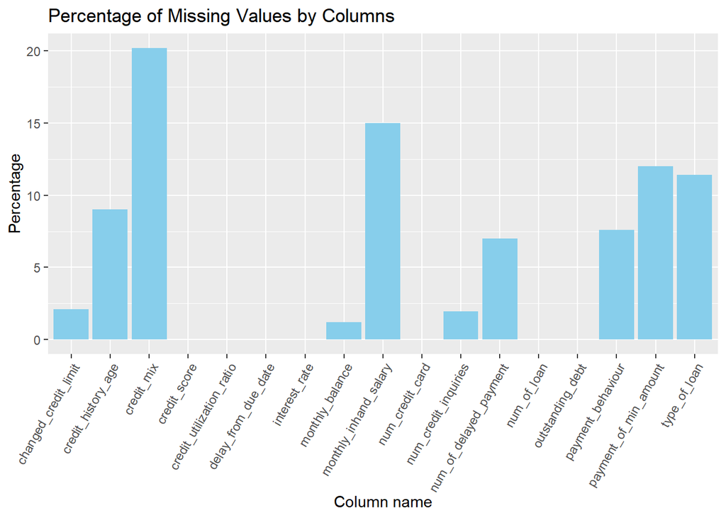

```r
missing_percentage <- colMeans(is.na(df_cleaned)) * 100
plot_data <- data.frame(column = names(df_cleaned), missing_percentage = missing_percentage)

ggplot(plot_data, aes(x = column, y = missing_percentage)) +
  geom_bar(stat = "identity", fill = "skyblue") +
  labs(title = "Percentage of Missing Values by Columns",
       x = "Column name", y = "Percentage") +
  theme(axis.text.x = element_text(angle = 60, hjust = 1))
```

Figure : Histogram showing the percentage of missing value

Based on the Figure above , it shows that “credit_mix” has the highest percentage of missing values, exceeding 20%. Following closely, “monthly_inhand_salary” exhibits approximately 15% missing values. “payment_of_min_amount” and “type_of_loan” each have around 12% missing values. On the other hand, “changed_credit_limit,” “credit_history_age,” “monthly_balance,” “num_credit_inquiries,” and “payment_behavior” display missing value percentages lower than 10%.

### cleaning missing value

```r
df_no_na <- df_cleaned

# replace all missing values of numeric data by mean
mean_col2 <- mean(df_no_na$credit_history_age, na.rm = TRUE)
mean_col3 <- mean(df_no_na$monthly_balance, na.rm = TRUE)
mean_col4 <- mean(df_no_na$monthly_inhand_salary, na.rm = TRUE)
mean_col5 <- mean(df_no_na$num_credit_inquiries, na.rm = TRUE)
mean_col6 <- mean(df_no_na$num_of_delayed_payment, na.rm = TRUE)

df_no_na$credit_history_age[is.na(df_no_na$credit_history_age)] <- mean_col2
df_no_na$monthly_balance[is.na(df_no_na$monthly_balance)] <- mean_col3
df_no_na$monthly_inhand_salary[is.na(df_no_na$monthly_inhand_salary)] <- mean_col4
df_no_na$num_credit_inquiries[is.na(df_no_na$num_credit_inquiries)] <- mean_col5
df_no_na$num_of_delayed_payment[is.na(df_no_na$num_of_delayed_payment)] <- mean_col6

# remove all missing values of categorical data
df_no_na <- na.omit(df_no_na)
```

To handle missing value in numeric data, we decided to replace them with the mean value in to maintain the completeness of the dataset. However, categorical data could not be imputed in the same manner and were consequently removed from the dataset to maintain data integrity.

### Outliers

```r
numerical_cols <- sapply(df_no_na, is.numeric)
df_numerical <- df_no_na[, numerical_cols]
numeric_values <- names(df_numerical)
```

Split the numerical columns for the further graphing.

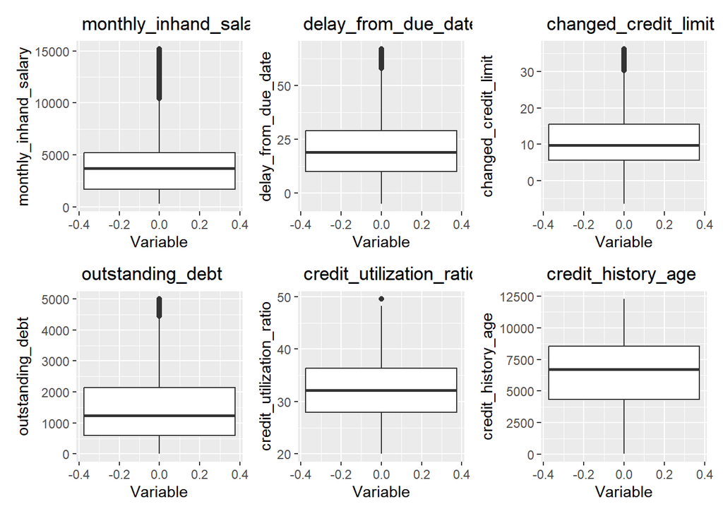

```r
# Boxplots
# Select values to estimate from numeric columns
values_to_remove <- c("num_credit_card", "interest_rate", "num_of_loan", "num_of_delayed_payment", "num_credit_inquiries", "monthly_balance")
values_to_estimate <- numeric_values[!numeric_values %in% values_to_remove]
plots <- list()
i <- 1
for (var in values_to_estimate) {
   p <- ggplot(df_numerical, aes_string(y = var)) +
    geom_boxplot() +
    labs(title = paste("", var), x = "Variable", y = var)
   plots[[i]] <- p
   i <- i + 1
}
plot_layout <- reduce(plots, `+`)
plot_layout + plot_layout(ncol = 3)
```

Draw the boxplots for all the numerical columns. We can see it’s clear that variables “inhand_salary”, “delay_from_due_date”, “changed_credit_limit”, “outstanding_debt”, “credit_utilization_ratio” seem to be influenced by outliers. But considering there might be some special conditions like reasonable minority of high income, we decide to use histogram for further insight.

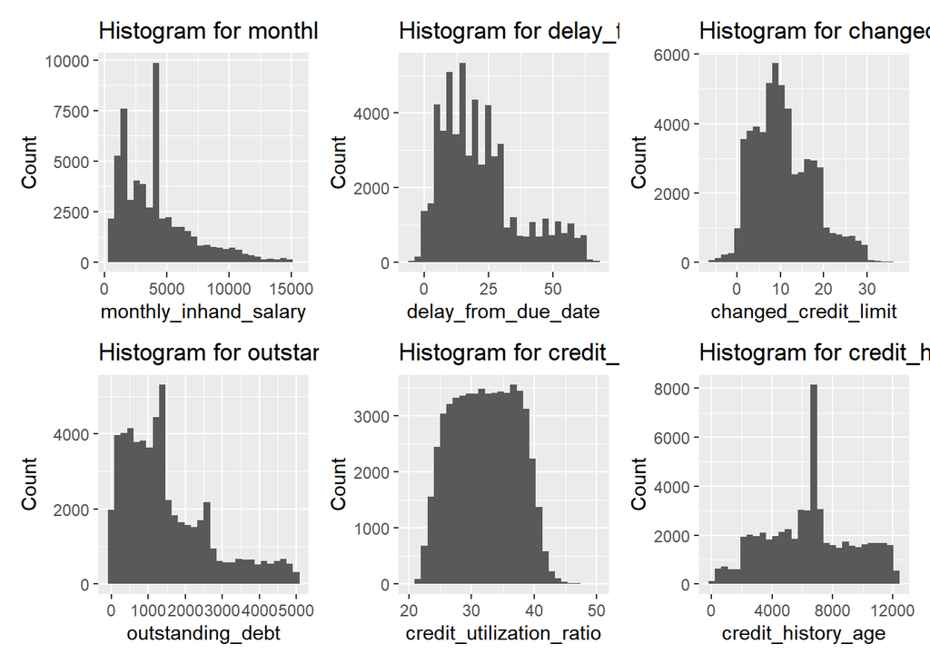

```r
# Histgrams of all
plots <- list()
i <- 1
for (var in values_to_estimate) {

  p <- ggplot(df_no_na, aes_string(x = var)) +
    geom_histogram(bins = 30) +
    labs(title = paste("Histogram for", var), x = var, y = "Count")
  plots[[i]] <- p
   i <- i + 1
}
plot_layout <- reduce(plots, `+`)
plot_layout + plot_layout(ncol = 3)
```

According to histograms, we found that although attributes like “monthly_inhand_salary” is skewed, it remains reasonable to keep the raw data because it declines slowly and continuously, which is similar to real income distribution. Therefore, only “credit_utilization_debt” needs processing.

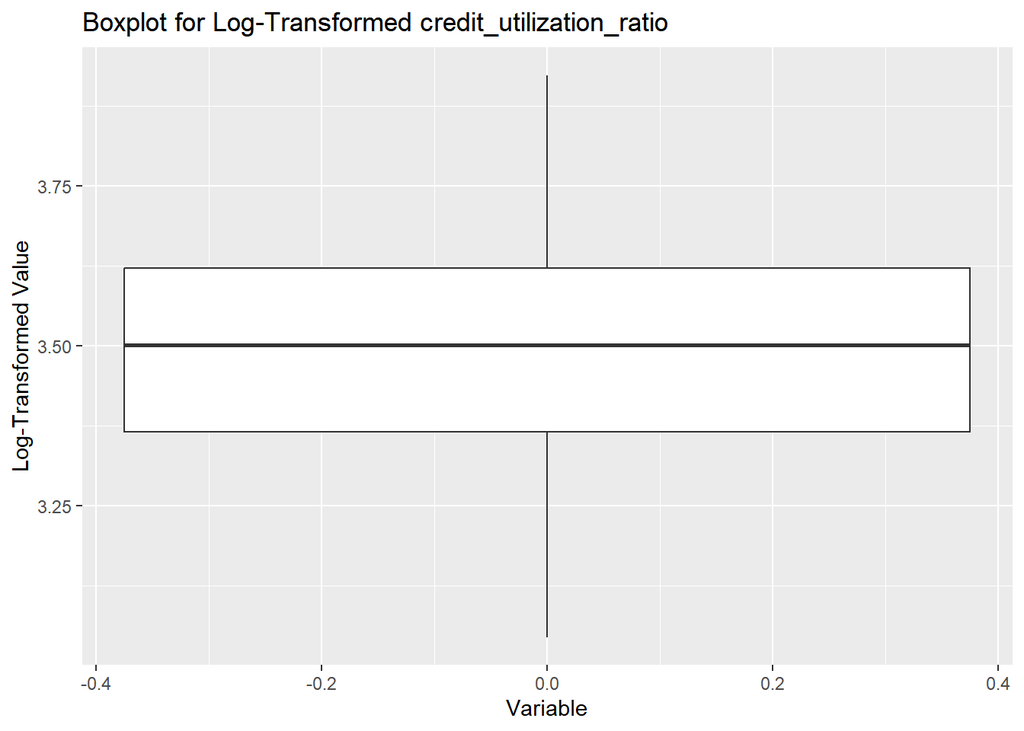

```r
# Apply log transformation to df_numerical
to_log_value <- c("credit_utilization_ratio")
df_to_log <- df_numerical[to_log_value]
df_numerical_log <- df_to_log
df_numerical_log[] <- lapply(df_numerical_log, function(x) if(is.numeric(x)) log(x + 1) else x)

# Boxplots
for (var in to_log_value) {
  p <- ggplot(df_numerical_log, aes_string(y = var)) +
    geom_boxplot() +
    labs(title = paste("Boxplot for Log-Transformed", var), x = "Variable", y = "Log-Transformed Value")
  print(p)
}
```

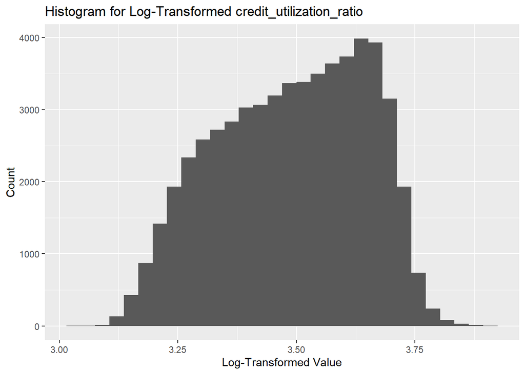

```r
# Histograms
for (var in to_log_value) {
  p <- ggplot(df_numerical_log, aes_string(x = var)) +
    geom_histogram(bins = 30) +
    labs(title = paste("Histogram for Log-Transformed", var), x = "Log-Transformed Value", y = "Count")
  print(p)
}
```

```r
df_numerical[to_log_value] <- df_numerical_log
df_no_na[numeric_values] <- df_numerical
head(df_no_na)
```

```
##   monthly_inhand_salary num_credit_card interest_rate num_of_loan
## 2              4194.171               4             3           4
## 4              4194.171               4             3           4
## 5              1824.843               4             3           4
## 7              1824.843               4             3           4
## 8              1824.843               4             3           4
## 9              3037.987               4             6           1
##                                                          type_of_loan
## 2 Auto Loan, Credit-Builder Loan, Personal Loan, and Home Equity Loan
## 4 Auto Loan, Credit-Builder Loan, Personal Loan, and Home Equity Loan
## 5 Auto Loan, Credit-Builder Loan, Personal Loan, and Home Equity Loan
## 7 Auto Loan, Credit-Builder Loan, Personal Loan, and Home Equity Loan
## 8 Auto Loan, Credit-Builder Loan, Personal Loan, and Home Equity Loan
## 9                                                 Credit-Builder Loan
##   delay_from_due_date num_of_delayed_payment changed_credit_limit
```

[output cut: 27 more lines]

We can see there’s no outliers after log operation.

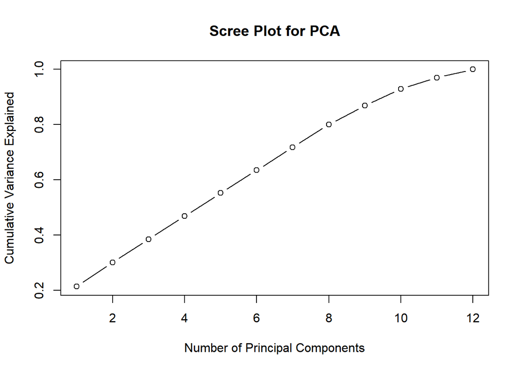

```r
# Standardize the numerical data
scaled_data <- scale(df_numerical)

# Perform PCA
pca_result <- prcomp(scaled_data)

# Plot Eigenvalues
eigenvalues <- pca_result$sdev^2
cumulative_variance <- cumsum(eigenvalues) / sum(eigenvalues)

# Plot the scree plot
plot(1:length(eigenvalues), cumulative_variance, type = "b",
xlab = "Number of Principal Components",
ylab = "Cumulative Variance Explained",
main = "Scree Plot for PCA")
```

we decided to performs Principal Component Analysis on the dataset. First, it standardizes the numerical data using the scale function to ensure that each variable has a mean of zero and a standard deviation of one, which is a common preprocessing step in PCA to give equal importance to all variables. Next, it applies PCA using the prcomp function, which calculates the principal components based on the standardized data. The eigenvalues, representing the amount of variance each principal component explains, are extracted from the PCA result. These eigenvalues are then used to calculate the cumulative variance explained by each principal component. Finally, the code generates a scree plot, a visual representation of the eigenvalues against the number of principal components, helping to determine the optimal number of components to retain based on the amount of variance they explain.

### Highly correlated features

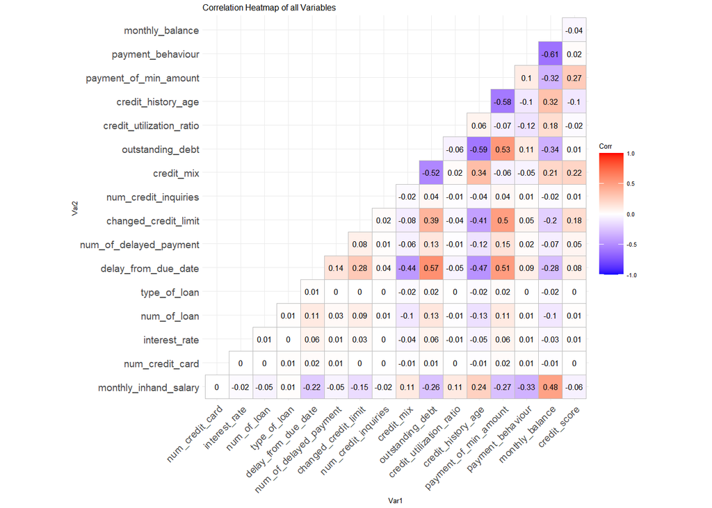

```r
# convert all attributes in df_no_na to factor type
categorical_data_factors <- lapply(df_no_na, as.factor)
categorical_data_numeric <- lapply(categorical_data_factors, as.numeric)
df_numeric <- as.data.frame(categorical_data_numeric)

# correlation check
correlation_plot <- model.matrix(~0 + ., data = df_numeric) %>%
  cor(use = "pairwise.complete.obs") %>%
  ggcorrplot(show.diag = FALSE, type = "lower", lab = TRUE, lab_size = 2) +
  ggtitle("Correlation Heatmap of all Variables")
correlation_plot + theme_minimal(base_size = 5) +
  theme(axis.text.x = element_text(size = 7, angle = 45, hjust = 1)) +
  theme(axis.text.y = element_text(size = 7))
```

Figure : Correlation heatmap of all features

### Data balance

```r
library(ggplot2)
library(readr)

suppressWarnings(data <- read.csv("F:/work/5003/assignment/archive/train.csv"))
table(data$Credit_Score)
```

```
##
##     Good     Poor Standard
##    17828    28998    53174
```

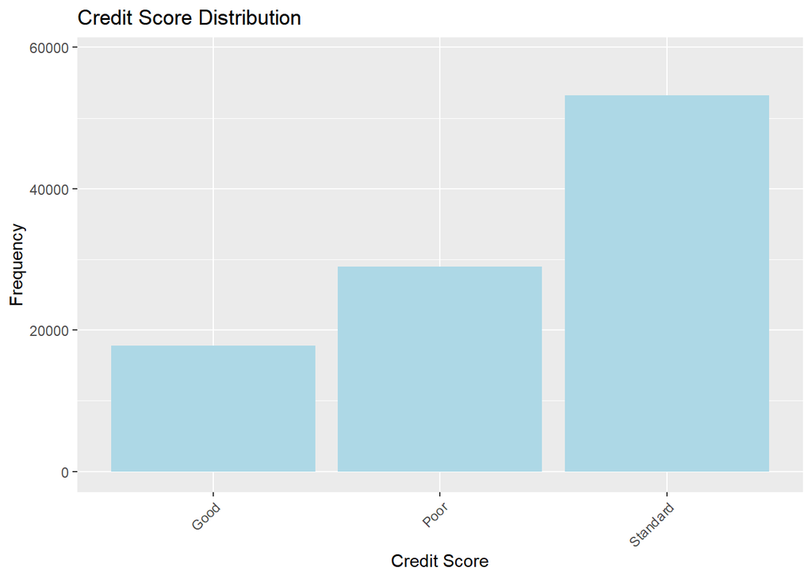

```r
# Calculate the frequency of each category
class_counts <- table(data$Credit_Score)

# bar chart
ggplot(data = data.frame(Credit_Score = names(class_counts), Frequency = as.numeric(class_counts)), aes(x = Credit_Score, y = Frequency)) +
  geom_bar(stat = "identity", fill = "lightblue") +
  labs(title = "Credit Score Distribution", x = "Credit Score", y = "Frequency") +
  theme(axis.text.x = element_text(angle = 45, hjust = 1)) +
  coord_cartesian(ylim = c(0, max(class_counts) * 1.1))
```

```r
library(caret)
library(lattice)
X <- data[, -which(names(data) == "Credit_Score")]
y <- data$Credit_Score
index <- createDataPartition(y, p = 0.7, list = FALSE)
X_resampled <- X[index, ]
y_resampled <- y[index]
table(y_resampled)
```

```
## y_resampled
##     Good     Poor Standard
##    12480    20299    37222
```

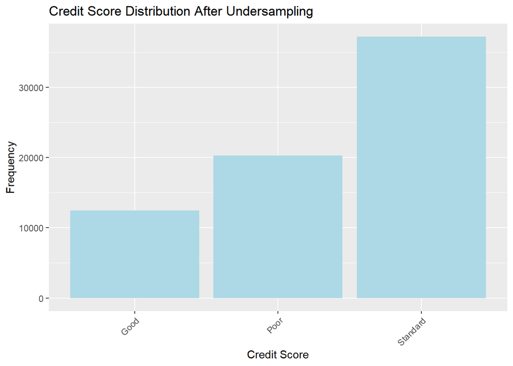

```r
resampled_data <- data.frame(
  Credit_Score = rep(names(y_resampled), y_resampled)
)

ggplot(resampled_data, aes(x = y_resampled)) +
  geom_bar(fill = "lightblue") +
  labs(title = "Credit Score Distribution After Undersampling", x = "Credit Score", y = "Frequency") +
  theme(axis.text.x = element_text(angle = 45, hjust = 1))
```

### Evaluation metrics

Since we are doing a classification problem, there are few approaches to check the performance of the model.

Confusion Matrix: Since we are predicting three class for the outcome variable “credit_score”, we can create a 3X3 confusion matrix and then calculate the TP, TN, FP, FN value for each class. The confusion matrix allows us to measure Recall, Precision, Accuracy, F1-score, and the AUC-ROC curve.

Precision, Recall and Accuracy: precision measures the percentage of predictions made by the model that are correct, while recall measures the percentage of relevant data points that are correctly identified by the model. Accuracy measures how often a machine learning model correctly predicts the outcome. We can use the metrics to test the accuracy of prediction and evaluate the performance of the model in a easy manner.

F1-score: F1 score is an alternative machine learning evaluation metric that assesses the predictive skill of a model by elaborating on its class-wise performance rather than an overall performance as done by accuracy. F1 score combines two competing metrics- precision and recall scores of a model. A high F1 score indicates a well-balanced performance, demonstrating that the model can concurrently attain high precision and high recall. A low F1 score signifies a trade-off between recall and precision, implying that the model has trouble striking that balance.

AUC curve: The Area under the ROC Curve (AUC) measures the total area beneath the Receiver Operating Characteristic curve (ROC), which ranges from (0,0) to (1,1). This metric offers a aggregate evaluation of performance, summarizing how well the model distinguishes between different classes across all possible thresholds. AUC is particularly useful for balancing sensitivity and specificity. Higher AUC values indicate better differentiation between positive and negative classes, making it a useful metric for comparing models. Additionally, a high AUC suggests that the model is effective at making prediction.

# overll and the plan of EDA

Data collection and pre-processing (March 20-March 25)

-Define the objectives and scope of the project.

-Collect the required dataset for the project and perform initial data validation and cleaning.

-Deal with missing values and outliers in the data.

Exploratory Data Analysis(March 26-April 4)

-Explore the basic statistical information of the customer data, such as age distribution, income distribution, indebtedness, etc.

-Draw box-and-line diagrams, histograms, etc. of customer data to observe the distribution of customer characteristics.

-Use visualisation tools to perform exploratory visualisation of data to discover patterns and trends in the data.

-Use visualisation tools such as heat maps to explore correlations between features.

-Analyse each feature in the customer data to see how it relates to the creditworthiness classification, analyse factors that may affect creditworthiness, such as income and job type, and remove features that are not highly correlated

-Features with high dimensionality, consider dimensionality reduction using principal component analysis to reduce model complexity.

Model Selection and Evaluation Discussion(April 5-April 9)

-Discuss and select suitable classifiers for the classification problem such as KNN, LR, SVM, AdaBoosting , Neural Networks etc.

-Discuss the use of techniques such as cross-validation to tune the model or not

-Discuss the evaluation metrics required for the classification problem

Summarise the results and write a report(April 10 - April 14)

-Summarise the results and write a report.

# How to split data and the choose of classifier

```r
library(caret)
set.seed(5003)
train_indices <- createDataPartition(df_no_na$credit_score, p = 0.8, list = FALSE)
train_data <- df_no_na[train_indices, ]
test_data <- df_no_na[-train_indices, ]
```

With the credit_score as the target variable, we will split the dataset into train_data and test_data.

For the classifier, our dataset aims to predict individuals’ credit scores (good, standard, poor) based on various factors. We’ll discuss the suitability of four classification algorithms for this task:

K-Nearest Neighbors (KNN): Effective for multi-class prediction and similarity-based classification. Logistic Regression (LR): Classic, interpretable, and suitable for analyzing feature impact. Support Vector Machine (SVM): Ideal for high-dimensional data and complex decision boundaries. AdaBoosting: Ensemble method handling imbalanced classes and focusing on difficult instances. Each algorithm offers unique strengths for accurately classifying credit scores based on features like monthly salary, credit history, and payment behavior. The choice depends on factors like model complexity, interpretability, and performance requirements, and a thorough evaluation is crucial for selecting the best-suited algorithm.